# Project 1

Padhraic Gorham| D22126376

1. Create a function which simulates the roll of `n` dice (where`n` > 3 is specified by the user), returns the value of the min value(s) and their positions in the sequence of values obtained and calculate their sum.

```r
#function to simulate n rolls of dice
dice_rolls <- function(nrolls = 3){

  #if statement to check if nrolls are less than 3

  if (nrolls < 3) stop('nrolls cannot be less than 3 ')

  rolls <- sample(1:6, size = nrolls, replace = TRUE)

  #gets the minimum value from the sequence.

  min <- min(rolls)

  #calculates the number of times they are in the sequences

  seq <- length(which(rolls== min))

  #Gets the positions in the sequence of the values obtained

  position <- which(rolls == min)

  #sums the values obtained together.

  sum <- min*seq


   list(min = min,

       seq = seq,

       position = position,

       sum = sum)

}

set.seed(8)
UD <- dice_rolls(95)

print(UD)
```

```
$min
[1] 1

$seq
[1] 16

$position
 [1]  6 17 18 29 44 50 55 59 65 66 69 81 84 88 89 93

$sum
[1] 16
```

2. Three dice (`D_1`, `D_2`, `D_3`) are rolled and let `S` be their sum. Use R to:
   - Print all the sequences such that `D_1` ana `D_2` are both greater than 4 and `S` < 14.
   - Find the conditional probability that `D_1` ana `D_2` are both greater than 3 given that `S` < 15.
   - Find the probability that either the sum of the first two dice is lower than 6 or that `S` < 7.

```r
# select a dice
die <- 1:6

# sample space of 3 dice with 216 outcomes

rolls <- expand.grid(die, die, die)
R <- data.frame(rolls, rowSums(rolls))

# assign names to the columns of the grid

colnames(R) <- c("D_1", "D_2", "D_3", "S")

#the subset of R that has that D_1 ana D_2 are both greater than 4 and S < 14

a <- subset(R, R$D_1 > 4 & R$D_2 > 4 & R$S < 14)

print(a)
```

|  | D_1 | D_2 | D_3 | S |
| --- | --- | --- | --- | --- |
| 29 | 5 | 5 | 1 | 11 |
| 30 | 6 | 5 | 1 | 12 |
| 35 | 5 | 6 | 1 | 12 |
| 36 | 6 | 6 | 1 | 13 |
| 65 | 5 | 5 | 2 | 12 |
| 66 | 6 | 5 | 2 | 13 |
| 71 | 5 | 6 | 2 | 13 |
| 101 | 5 | 5 | 3 | 13 |

```r
#conditional probability that D_1 and D_2 are both greater than 3 given that S < 15

sum(R$D_1 > 3 & R$D_2 > 3 & R$S < 15) / sum(R$S < 15)
```

```
[1] 0.1836735
```

```r
#sum of the first two dice is lower than 6 or that S < 7

sum((R$D_1 + R$D_2) < 6 | R$S < 7) / dim(R)[1]
```

```
[1] 0.2777778
```

3. A random variable `X` is defined as `x <- c(-2, -1, 0, 1, 2, 3, 4)`, `p_x <- c(0.10, 0.15, NA, 0.30, 0.05, 0.10, 0.10)`. Use R to:
   - Find the missing PMF value.
   - Find the probability that `X` is lower than 1.
   - Find the conditional probability that `X` is greater than -1 given that `X` is greater that -2.

```r
x <- c(-2, -1, 0, 1, 2, 3, 4)

# the p_x with the missing NA value

p_x <- c(0.10, 0.15, NA, 0.30, 0.05, 0.10, 0.10)

#since probabilities have to a add to 1 we can remove the 'NA' value and sum the rest then take the sum and subtract it from 1 giving us the object 'a'

a <- 1 - sum(p_x, na.rm = TRUE)

#This function replaces the 'NA' value with a which is 0.20

p_x[is.na(p_x)] <- a

p_x
```

```
[1] 0.10 0.15 0.20 0.30 0.05 0.10 0.10
```

```r
#we assign F_x to the cumulative sum of the probabilities in the 'new' p_x

F_x <- cumsum(p_x)

#probability that X is less than 1 which is the same the cumulative sum equal to 0

F_x[x == 0]
```

```
[1] 0.45
```

```r
#Conditional probability that `X` is greater than -1 given that `X` is greater that -2

1 - (F_x[x == -2] / F_x[x == -1])
```

```
[1] 0.6
```

4. Suppose that 60% of voters support Proposition A. You poll a sample of 200 voters. Let `X` be the random variable modelling the number of voters of the sample supporting Proposition A. Use R to:
   - Find the probability that `X` is greater than 130.
   - Find the mode of `X`, i.e., the value of `X` that is most likely to be observed in the sample.
   - Find the conditional probability that `X` is lower than 100 given that `X` is greater than 90.

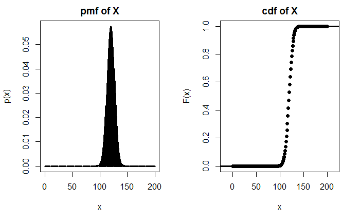

```r
n <- 200
p <- 0.60
x <- 0:n

# I get the sample of the data using the dbinom function
p_x <- dbinom(x,
              size = n,
              prob = p)

# I get the cumulative probability of the data using the pbinom function
F_x <- pbinom(x, size = n, prob = p)

#I want to plot the data to see what the distribution looks like
par(mfrow = c(1, 2))

plot(x, p_x, lwd = 3, type = 'h', main = 'pmf of X', ylab = 'p(x)')

cdf <- stepfun(x, c(0, F_x))
plot.stepfun(cdf, verticals = FALSE, do.points = TRUE,
             pch = 16, lwd = 3,
             main = 'cdf of X',
             ylab = 'F(x)')
```

```r
#this function plots the probability of X greater than 130
1 - pbinom(129, n, p)
```

```
[1] 0.08439778
```

```r
#I wrote ths function to get the mode of the data with length of 1
getmode <- function(v) {
 uniqv <- unique(v)
 uniqv[which.max(tabulate(match(v, uniqv)))]
}

result <- getmode(p_x)
print(result)
```

```
[1] 2.58225e-80
```

```r
length(which(p_x== result))
```

```
[1] 1
```

```r
#Conditional probability that `X` is lower than 100 given that `X` is greater than 90
F_x[91]  / F_x[99]
```

```
[1] 0.01222179
```